# Spatial Transcriptomics Technologies

spatial transcriptomics

experimental design

Explore the current landscape of spatial transcriptomics technologies. Focusing on contrasting sequencing-based and imaging-based platforms to show how they differ in resolution, throughput and sensitivity. By the end, you will be informed on which technology is best suited for your biological question.

Author

Noor Sohail

Published

July 22, 2025

Keywords

Imaging-based, Sequencing-based, Visium, MERFISH, seqFISH

Approximate time: 30 minutes

## Learning objectives

In this lesson, we will:

- Describe the evolution of high-throughput sequencing
- Highlight the differences between sequencing- and imaging-based technologies
- Define the advantages and disadvantages of different spatial transcriptomics technologies

## Overview of lesson

Before we touch any data, we need to orient ourselves on the spatial transcriptomics landscape. In this lesson we compare imaging- (MERFish, Xenium) and sequencing-based platforms (Visium HD, Slide-seq) so that you can make sense of which technology is right for your research question. Each method is different in its resolution, coverage, tissue compatibility and practical constraints.

Knowing the advantages and disadvantages of each method will allow you to make an informed decision about which technology is best for your research question. In addition, some computational methods/algorithms are better suited to certain types of spatial transcriptomics results.

## High-throughput sequencing overview

Over the years, transcriptomics technologies have evolved rapidly from bulk sequencing, to single-cell sequencing, all the way to the current spatial transcriptomics methods.

[figure not shown]

Figure 1: Lego representation of the evolution of sequencing technologies, showing more specificity and structure with each advancement.  
*Image source: [Bo Xia Lab](https://www.boxialab.org/news)*

### Bulk and single-cell sequencing

**Bulk RNA-seq** is a method for comparing the averages of cellular expression for a population of cells. This method can be a good choice if looking at **comparative transcriptomics** (e.g. samples of the same tissue from different species) and for quantifying expression signatures in disease studies. It also has potential for the discovery of disease biomarkers if you are not expecting or not concerned about cellular heterogeneity in the sample.

To contrast, **single-cell sequencing** is a method for measuring gene expression on a per-cell basis. This method is ideal for studies containing **cellular heterogeneity** where the differences between celltypes or cell states are the primary focus.

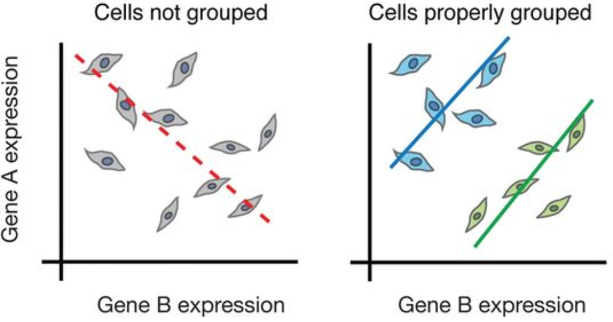

Figure 2: Comparison of bulk and single-cell RNA sequencing approaches, showcasing loss of cellular resolution in bulk due to averaging.  
*Image source: [Trapnell et al. (2015)](https://dx.doi.org/10.1101/gr.190595.115)*

To give an example, if we look at the image above, we can see that there are two cell types (blue and green) that have different expression patterns for genes A and B. If we were to analyze this data in bulk (left), we would not be able to detect the correct association between the genes. However, if we properly group the cells by cell type (right), we can see the correct correlation between the genes.

### Spatial transcriptomics

Spatial transcriptomics extends the concept of single-cell sequencing further by adding the coordinates for each cell or spot on a slide. This allows us to understand both the molecular and spatial context for gene expression. Many of the challenges of scRNA-seq are also present in spatial transcriptomics.

Studies that focus on the tissue microenvironment benefit from location information, as nearby cells are more likely to interact with one another. Another potential application is the ability to annotate key areas of a tissue based upon the histological features of the tissue, which can be particularly useful for studies of cancer and other diseases.

These visuals typically come in the form of H&E (Hematoxylin and eosin) stains. Here, nuclei will be stained a purple/blue hue and the eosin colors the cytomplasm pink. Pathologists can use these stains to identify key areas of a tissue, as shown below:

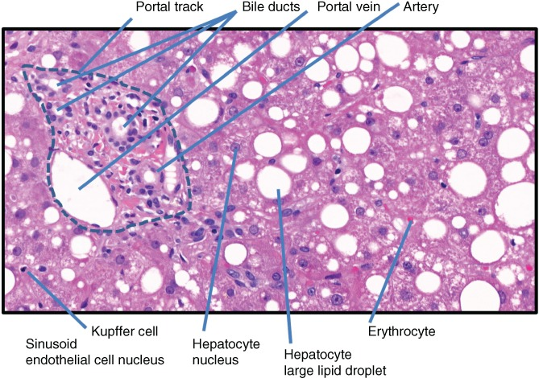

Figure 3: Example of histology slide from a liver biopsy, annotated by a pathologist.  
*Image source: [Holzinger et al. (2019)](https://pmc.ncbi.nlm.nih.gov/articles/PMC7017860/)*

Many of the challenges that arise in single-cell experiments are also present in spatial, for example:

- Large volume of data
- Low depth of sequencing per cell
- Technical variability across cells/samples
- Biological variability across cells/samples

Spatial transcriptomic technologies can be broadly categorized into two groups: **sequencing-based** and **imaging-based**. We will now discuss the different technologies within each of these categories as well as their advantages and disadvantages.

**Warning**

## Sequencing-based technologies

Sequencing-based methods are sometimes referred to as “spot-based methods” because the tissue is placed on a slide with a grid-like pattern. Similar to a microarray, each *spot* on the grid has a unique sequence (barcode) associated with its location. After the permeabilization step, RNA from the tissue binds to these barcode capture probes. Because we already know the location of each barcode in advance, we know which bin/spot a read comes from. Therefore, the output is the gene-expression of each bin as well as its associated location on the tissue.

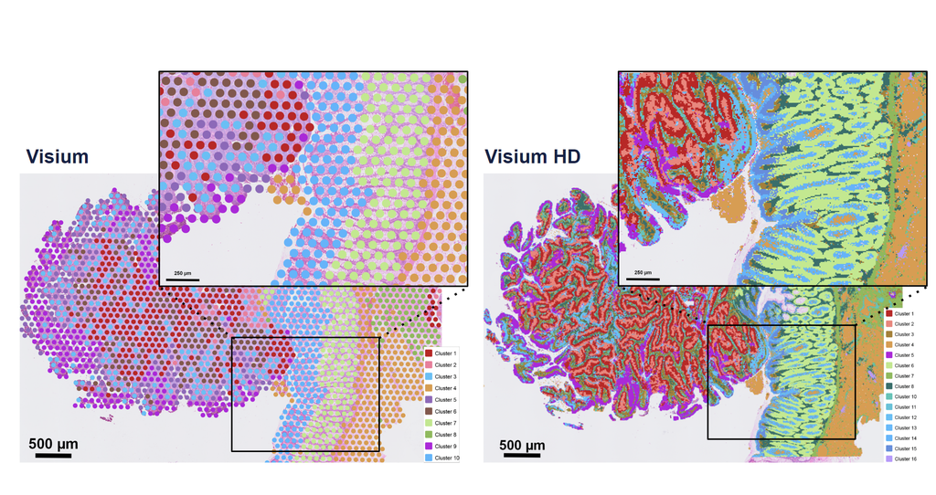

Figure 4: Comparison of Visium and Visium HD data in FFPE human colorectal cancer, showcasing the resolution that can be achieved with sequencing-based methods.  
*Image source: [10X Genomics: Your Introduction to Visium HD](https://www.10xgenomics.com/blog/your-introduction-to-visium-hd-spatial-biology-in-high-definition)*

The sizes of these spots vary per technology. Earlier sequecing-based methods had larger bins, which could contain several cells per spot. As the technology has evolved, the bin sizes have become smaller, allowing for near single-cell resolution.

### Summary of popular methods

In essence, these methods allow you to apply a grid to the tissue and quantify thousands of genes according to each square on the grid. Some popular technologies that belong to this category include:

Table 1: Summary of popular sequencing-based methods for spatial transcriptomics.

|  | Visium | Visium HD | Stereo-seq | Slide-seq |
| --- | --- | --- | --- | --- |
| **Vendor** | 10x Genomics | 10x Genomics | BGI Group | Curio Biosciences* |
| **Capture size** | ~6.5 × 6.5 mm capture area (×4 per slide) | ~11 × 11 mm–scale capture area (single array) | Up to ~1 × 1 cm chip (cm²‑scale field of view) | ~1 cm diameter puck (~80 mm²) |
| **Resolution** | 55 µm spot diameter; multicellular | ~2 µm “pixel” size; near single‑cell | 220 nm DNA nanoball spacing; subcellular | 10 µm beads; near single‑cell |
| **H&E** | Yes (same section) | Yes (same section) | No | No |
| **Tissue preservation** | FFPE and fresh frozen | Primarily FFPE; FF also supported | Fresh frozen | Fresh frozen |
| **Year released** | 2019 | 2023–2024 | 2022 (atlas) | 2019 |

**ImportantVisium HD**

We will be using Visium HD for the hands-on portion of this workshop.

### Advantages and disadvantages

**Advantages:**

- Analyses that make use of many genes at once (functional analysis, RNA velocity, etc.) can be done on these datasets as you are sequencing the entire transcriptome instead of a gene panel.
- Can be run on non-model organisms with greater ease.

**Disadvantages:**

- High-resolution experiments (Visium HD) can be very expensive
- Spots are not guaranteed to be a single-cell (can be multiple cells, or no cells at all)

## Imaging-based technologies

[figure not shown]

Figure 5: Showcase of MERFISH, an imaging-based technology, which can achieve single-cell resolution of tissues.  
*Image source: [Vizgen: Leading the Global Expansion of Spatial Transcriptomics](https://vizgen.com/vizgen-leading-the-global-expansion-of-spatial-transcriptomics/)*

Imaging-based spatial transcriptomics builds upon fluorescence in situ hybridization (FISH) to measure expression of genes using probes on a tissue. The transcripts are amplified such that multiple copies are located within a small spot. These reads then go through multiple cycles of imaging, where the probes will fluoresce when specific sequences are present. A camera captures these images and ultimately identifies the location and sequences for each of these reads.

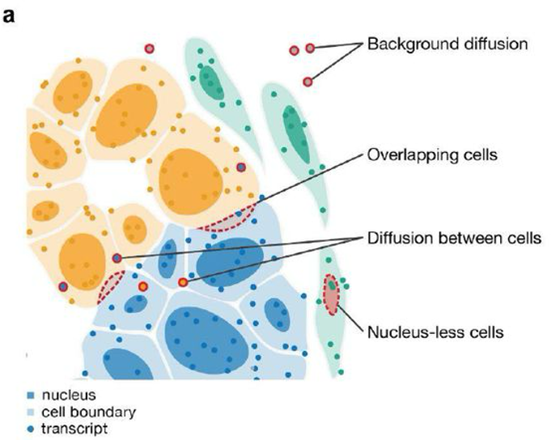

Figure 6: Schematic of how cell boundaries are establieshed using nuclear stain, cell boundary stains, and transcripts to identify cellular boundaries.  
*Image source: [Heidari et al. (2025)](https://www.biorxiv.org/content/10.1101/2025.03.14.643160v1.full)*

Many of these methods will also use a DAPI stain to identify both nuclear and cellular walls. This allows for the identification of cell boundaries to map transcripts to a singular cell. In this way, imaging-based technologies are able to capture single-cell level resoultion of tissues for the provided set of probes.

### Summary of popular methods

Table 2: Summary of popular imaging-based methods for spatial transcriptomics.

|  | seqFISH | MERFISH | Xenium |
| --- | --- | --- | --- |
| **vendor** | NA (academic method) | Vizgen | 10x Genomics |
| **Capture size** | Variable FOV; tiled imaging fields (typically mm-scale regions stitched across section) | Variable FOV; tiled imaging fields (mm-scale regions, stitchable to large areas) | Variable FOV; tiled high‑plex imaging over tissue sections (up to whole‑slide via tiling) |
| **Resolution** | Subcellular, subdiffraction (seqFISH/seqFISH+) | Subcellular (single‑molecule FISH) | Subcellular, targeted in situ (per‑cell calls with subcellular localization) |
| **H&E** | No (standard workflow uses fluorescence imaging only) | No (fluorescence imaging only) | (Yes) — H&E‑like morphology and protein markers supported; H&E compatibility in active development at time of review |
| **Tissue preservation** | Fresh frozen | FFPE and fresh frozen | FFPE and fresh frozen |
| **Year released** | 2014 (first seqFISH paper) | 2015 (first MERFISH paper) | 2022 (commercial launch of Xenium platform) |

### Advantages and disadvantages

**Advantages:**

- Can be used to evaluate the expression of a select panel of genes with high sensitivity and specificity
- Single-cell resolution

**Disadvantages:**

- Limited to a select panel of genes
- Segmentation is not a trivial task and requires careful pre-processing
- Challenging with non-model organisms as probes are necessary

## Summary of comparison

Table 3: Summary of the advantages and disadvantages of sequencing- and imaging-based spatial transcriptomics technologies.  
*Adapted from: [Single Cell Discoveries](https://www.scdiscoveries.com/blog/sequencing-vs-imaging-in-spatial-transcriptomics/)*

| **Feature** | Sequencing-based | Imaging-based |
| --- | --- | --- |
| **What they measure** | Whole transcriptome | Targeted panels |
| **Spatial resolution** | Multi-cell (spots/bins) to single cell | Single cell |
| **Sensitivity** | Broad detection; may miss low-abundance genes | High for targeted genes |
| **Limitations** | Mixing of cells in one spot | Limited number of probes |
| **Throughput (slides)** | High (parallel processing) | Lower (multiple imaging cycles) |
| **Throughput (genes)** | High (dozens of thousands) | Limited (hundred to thousand*) |
| **Cost** | More cost-effective at scale | Higher per sample |
| **Best for…** | Discovery projects | Validation projects |

## Experimental design considerations

**Warning**

Next Lesson >>

Back to Schedule